# Ford GoBike System Data

## by Adebayo Okesola

## Investigation Overview

In investigating the Ford GoBike Share dataset, a major point of concideration is to investigate the influence of Age of the riders on the distance covered and duration it takes to cover the distance. The main focus was on the distance (km), Age (years) and duration (hours).

## Dataset Overview

The Ford GoBike System Data has 16 columns and 183411 rows and its latest update was February 2019 which is one of the data set provided by Udacity. The Ford GoBike data set includes information about individual rides made in a bike-sharing system covering the greater San Francisco Bay area. In this data set some rows were dropped at a certain point due to missing data which causes consistency and validity issue. Also two columns start and end time were dropped because theY will not be required for this analysis.

## Age Distribution of Riders

This is to show the Age distribution of all riders in the dataset, It was observed that the maximun age is 118 while the minimum age is 18 years. From the plot it can be deduced that majority of the riders fall between the age of 18 to 40 years of age. while age 88 and 118 can be considered as outliers

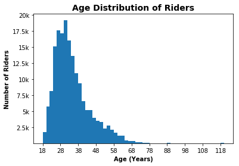

## Relationship Between Distance and Duration

This is to show what relationship exist between distance covered by the riders and the time taken to cover this distance. It was observed that there is a weak positive correlation between distance and duration it takes the rider to cover the distance. Also more of the riders cover a distance of 8 km in less than 5 hours.

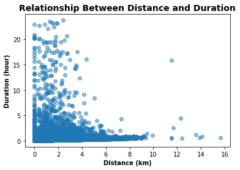

## Relationship Between Age and Duration

The relation between age and duration is to show how the age of the riders determine the time it they ride. This rlationship shows that riders who are 78 and above didn't spend much time compared which ridrs whos age is between 18 and 60 years of age.Thos who are between 18 and 60 years of age rode for a longer time although majority rode for less than 5 hours.

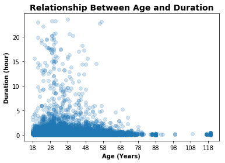

## Relationship Between Distance and Member Age

This is to determine the distance covered by riders and the age of the riders with respect to the distance. It was observed that majority of the riders covered between 0-8km and the respective age is between 18 - 80 years of age. While few rider between the age of 18 - 40 covers a distance of 10 - 16 km and only few riders above 80 years covered a distance of 0-6km.

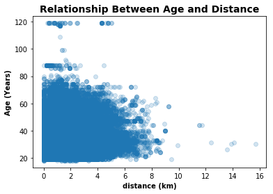

## Correlation Between Age, Distance and Duration

This is to show the correlation between age, distance and duration. it was observed that duration and member age have a weak negative correlation, member age and distance have weak positive correlation, while distance and duration have a positive weak correlation too but its stronger than that the correlation between member age and distance.

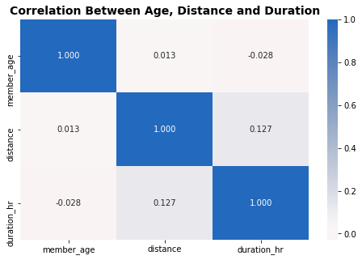